# Simulation study: Power and sample size calculations correlational studies

Xiaohe (Marina) Yue

## Introduction

A common research objective is to demonstrate that two measurements are highly correlated. One measurement, call it A, may reflect the severity of disease but is difficult or costly to collect. Another measurement, call it B, may be easier to collect and potentially related to measurement A. If there is strong association between A and B, a cost effective strategy for diagnosis may be to collect measurement B instead of A.

In this deliverable, you will perform a power and sample size calculation for a collaborator who is submitting a grant application to fund a study to show that two measurements are highly correlated. Reviewers of the grant want to fund studies that have a high likelihood of success, which in this setting is conclusively demonstrating that the correlation between A and B is greater than 0.8.

The researcher will collect both measurements on N individuals. The analysis will proceed by calculating a one-sided confidence interval. If the confidence interval is completely within the range from 0.8 to 1, then the researcher will consider the study to be a success: A conclusive demonstration that the correlation between A and B is greater than 0.8.

Power is the probability that the study will end in success when the true underlying correlation is, in fact, greater that 0.8. (Note the connection to Type II error (β): power = 1 - β.) Your collaborator needs you to estimate power for different combinations of sample size and the true population correlation. Let the sample size be 25, 50, 75, and 100. Let the population correlation range from 0.8 to 0.95.

## Simulation Study

Codes below are about our simulation study. Here we store our simulated outputs into a variable called “power”. The null correlation is set to be 0.8 since according to the requirements, correlation that greater than 0.8 between A and B is what we want. We repeat 5000 times here. In order to test for the association between A and B, we use the “cor.test” in R. We set the alternative to be “greater” since we only want it to be one-sided positive. One more thing that should be mentioned is that we apply the study to different sample size, which are 25, 50, 75, and 100. We can see from the graph that when the sample size is increasing, slope is increasing which means under the same correlation, study that with higher sample size gets higher power. We again recall that power is the probability of making a correct decision (to reject the null hypothesis) when the null hypothesis is false. Therefore, we can conclude that when sample size increases, the probability that the study will end in success when the true underlying correlation is, in fact, greater that 0.8 will be higher when the population correlation stays the same.

```r
set.seed(20394)

fun1 <- function(N){
power <- rep(NA)
N
null_correlation <- 0.8
R <- 5000
mu <- c(0,0)


for (j in 1:16){
  detect <- rep(NA, R)
  sigma <- array(c(1,0.79+0.01*j,0.79+0.01*j,1), c(2,2))

    for(i in 1:R){
        data <- rmvnorm(N, mean = mu, sigma = sigma)
        results <- cor.test(x = data[,1], y = data[,2], alternative = "greater")
        detect[i] <- results$conf.int[1] > null_correlation
    }
  power[j] <- mean(detect)

}
lines(seq(0.8,0.95,0.01),power,col=N,type = "l")
text(0.87,power[8],N,pos=2,cex=0.7,col=N)

}
```

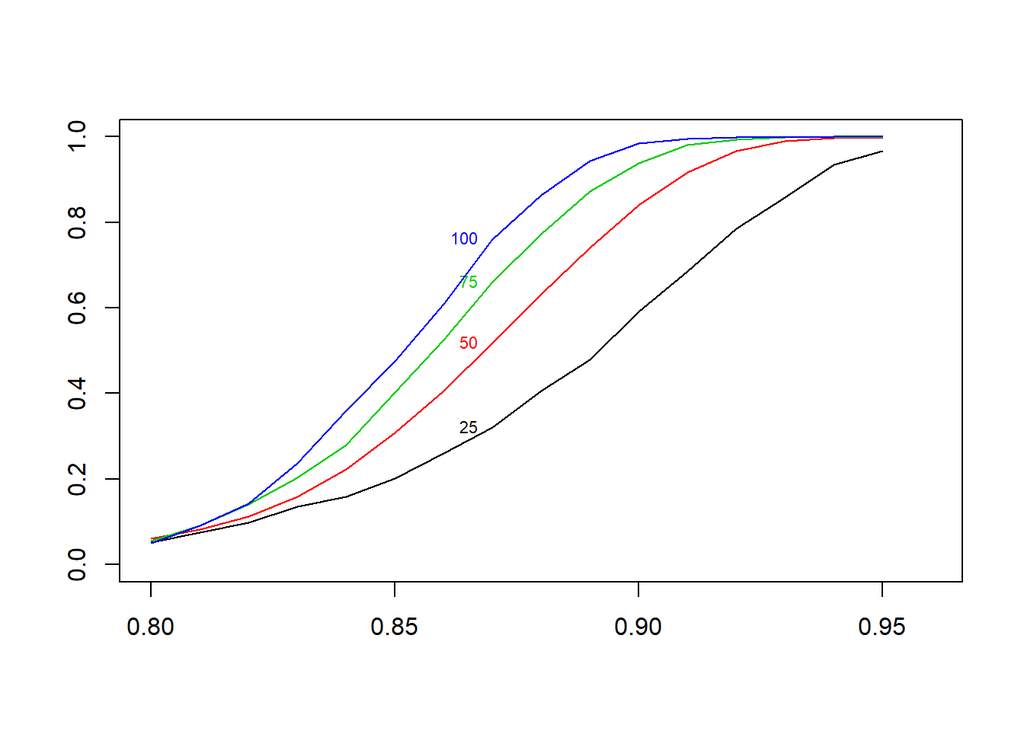

```r
plot.new()
plot.window(xlim=c(0.8,0.96),ylim=c(0,1),xlab='correlation',ylab='power')
for (N in c(25,50,75,100)){
  fun1(N)
}
axis(1)
axis(2)
box()
```